# Project Proposal

Author

Affiliation

Luke Gooding

University of Pennsylvania

Published

May 10, 2024

## Introduction

Trinidad and Tobago earned its independence in 1962. In that transition period from colony to independent state, education was used as a means of post-colonial nation building (London 1997). The emerging education system, therefore, emphasized access and quality with the message being that education is central to the economic development of any nation (London 1997). The country consequently has a robust and ever expanding public schooling system which, as of 2019, educates 92% of primary school students across 558 institutions and 88% of secondary school students across 199 institutions (“Education Statistics - Central Statistical Office” 2021).

Importantly, one of the major stakeholders in Trinidad and Tobago’s education system are churches. Before independence, most of the nation’s schools were run by various religious boards. Churches owned and managed these schools with autonomy and were allowed to charge enrolled students. With the goal of universal secondary education, the government took over the responsibility of funding these schools, which are now known as government ‘assisted’ or denominational schools (London 1997). They standardized syllabi and exams across all the nation’s public schools while allowing these religious boards to maintain administrative responsibility and their religious ethos. This arrangement is codified in The Concordat of 1960 (“Policy Documents – Ministry of Education” n.d.).

However, according to the Concordat, denominational secondary schools have a special privilege:

*The Principals of Assisted Secondary Schools will make available a minimum of 80 per centum of the First Form entry places to those who, by passing the test, qualify on the results of the Common Entrance Examination for free secondary education…The Principals will be free to allocate up to 20 per centum, the remaining places as they see fit provided normally that the pass list of the Common Entrance Examination serves to provide the pupils. (“Policy Documents – Ministry of Education” n.d.)*

This part of the Concordat, colloquially known as the ‘20% list’ is the subject of my research. Campbell Campbell (1997) refers to the Concordat as one of many colonial holdovers present in our education system that perpetuates elitism. Coloquially, we refer to elite secondary schools as ‘prestige schools’.

‘Prestige schools’ are secondary schools that are considered high performing and are usually ranked first in students’ 4 choices. Some refer to these schools as ‘first choice schools’. To operationalize this term, I have devised a definition:

*If the number of students that chose a school as their first choice exceeds the capacity of that school, this school will be classified as a ‘prestige school’.*

I can then order schools based on cutoff scores (similar to the way the Assignment Algorithm works). For example, if 250 students choose school X but school X has a capacity of 100, then X will be considered a prestige school with a cutoff score equal to the score of the 100th best performing student. I believe my definition is suitable because I think ‘prestige’ as a construct is more about perception than reality. It is possible to develop a ranking system for secondary schools based on historical academic and extracurricular performance but for the purpose of my analysis, the aggregated perception of students and their parents is more meaningful, and this is proxied by their choices. These choices set up a system of demand and supply where some schools have a greater demand than others, creating ‘prestige’. It is not my goal to explain the underlying reason for this ‘prestige’ but rather to identify it and investigate a particular externality.

These ‘prestige’ schools also tend to be government assisted schools with the 20% list privilege. It then begs the question how this 20% list is used today. Remember, these churches went from having control over 100% of their incoming students in a time when secondary education was expensive but in low demand to now only controlling 20% of their incoming students in a time when secondary education is free but in high demand.

Unfortunately, there are not many studies identifying and focusing on ‘prestige schools’ in particular. Jackson Jackson (2013), looked at a special subset of ‘selective schools’. He showed that attending schools with higher-achieving peers increases academic performance and that short-run increases in peer achievement improve outcomes only at high-achieving selective schools. Given this, it is safe to say that access to prestige schools will likely increase academic success and the resulting benefits that come from that.

On the other hand, a study conducted by the Inter-American Development Bank shows that there are no meaningful differences between the academic outcomes of government versus government assisted secondary schools between the ages of 10 and 15 in terms of dropout rates or examination performance at age 15 in Trinidad and Tobago (Beuermann, Jackson, and Sierra 2015). This is despite the study also noting large differences in teacher and peer quality between school types. The research made no mention of ‘prestige schools’ which I theorize is an outlying subset of government assisted schools.

This work is intended to fill what I think is a necessary gap by informing citizens and policy makers about the mechanisms behind the 20% list. If there is evidence of inequity, whether from this study or others; parents, teachers and policy makers should mobilize to address this issue. Equity in education is not a new phenomenon:

*One of the best established findings of educational research is that students’ social class and their attainment at school are linked. This is a worldwide phenomenon. Students from more prestigious social class backgrounds or higher-income families tend to obtain higher marks and examination grades, and are then more likely to stay on in any education system that celebrates qualifications over equity.* (Gorard and Siddiqui 2019)

Globally, the persistence of the SEA exam and similar 11-plus examinations is the subject of much research. 11-plus exams have been discredited from both a psychometric and philosophical point of view by education authorities committed to equality of opportunity and non-elitism (Mackenzie 1989). MacKenzie Mackenzie (1989) posits that the system persists in Trinidad and Tobago as a necessary mechanism to resolve the incredible demand for prestige schools. It is only through the improvement of non-prestige schools and the change in attitude of citizens toward them can the conversation about removing SEA be possible. MacKenzie Mackenzie (1989) suggests that, in the short term, modifications to the SEA examination will go some way to mitigating its deleterious effects.

In summary, I believe any threat to equity in education that can be reasonably remedied ought to be and I think that a close look at the 20% list and transition process is a good place to start. As Lisle Lisle et al. (2009) stated: *the future of policy on the use of secondary school entrance examinations lies not in further tinkering or experimentation without evidence, but in developing a robust ongoing monitoring and evaluation system to provide information on examination processes and outcomes*.

### Theory and Hypothesis

The existence of ‘prestige schools’ has many effects on individuals navigating the transition process. Failure to get into a ‘prestige school’ can have negative emotional, social and psychological impact on students and hence the effort to avoid this failure would cause students to experience stress, anxiety and fear (Cunningham 2021). Parents also often resort to investing in supplementary tutoring in preparation for the SEA exam (Barrow and Lochan 2012).

With such high stakes, the 20% list is a powerful tool. While its purpose is to allow principals to hand pick students who share the same religion and values as their institution, many have claimed that the 20% list is a tool to allow students of wealthy families to gain admittance to ‘prestige schools’. I am interested in whether or not the 20% list benefits wealthier families and generates inequity.

To be clear, nobody has done research explaining the mechanism behind the 20% list. Principals are given full autonomy in generating this list. Realistically, however, it is not the case that religion is the only factor that principals consider due to the sheer demand. I posit that they are influenced by those around them, whether teachers, parents, the administration, friends. I also posit that money and the promise of donations can play a role in the decision-making process. Based on my own experience (I choose not to disclose details), I can recall instances where parents have contacted principals in their child’s behalf to petition for their inclusion on the 20% list. Whether or not my personal anecdote hold weight, it is reasonable to think that there exists bias within a system without transparency. The goal of this study is to figure out if family wealth plays factors into the 20% list generation process.

I hypothesize that there is a significant relationship between the existence of the 20% list and rate of admittance of students from wealthy families to ‘prestige’ secondary schools. More specifically, I think that attending a private primary school increases your likelihood of being admitted to a prestige school.

### Empirical Extension

I will also test the strength of the relationship in question at different levels modeled after Jackson’s research (Jackson 2013). He ranks schools by mean incoming SEA scores. He then makes 3 categories: 1 to 30, 30 through 90 and Above 90 and compares the effect at each level. While my ordering system uses cutoff scores, I can model his categorization to determine if there are different strengths of the relationship between the 20% list and the rate of private school student admissions at the 1 to 10, 11-20 and 21-30 levels.

Ranking schools based on cutoff scores is a useful index for competitiveness of a school for two reasons. Firstly, in order for a school to have a cutoff score, there must be more students who choose the school as their first choice than there are spots available. Secondly, higher cutoff scores means higher performing, more competitive students.

## Research Design

To investigate this hypothesis, I will conduct a cross-sectional study of the 2017 SEA results and assignment data. This data contains the students’ primary school, 4 ranked choices of secondary schools, SEA scores and assigned secondary school and was provided to me by the Catholic Education Board.

### Data

| PRIMARY.SCHOOL | STUDENT.PIN | Gender | Age | COMMUNITY | X1st | X2nd | X3rd | X4th | English | Math | Essay | Composite | SECONDARY.SCHOOL.ASSIGNED |
| --- | --- | --- | --- | --- | --- | --- | --- | --- | --- | --- | --- | --- | --- |
| AGAPE TRAINING CENTRE | 1749329442 | M | 1208 | CALVARY HILL | 263 | 668 | 12 | 18 | 40 | 29 | 9 | 171.352 | JOHNSON'S FINISHING SCHOOL |
| AGAPE TRAINING CENTRE | 1969581574 | M | 1205 | PINTO ROAD | 190 | 193 | 75 | 12 | 38 | 21 | 8 | 164.498 | JOHNSON'S FINISHING SCHOOL |
| AGAPE TRAINING CENTRE | 6338256681 | M | 1400 | OROPUNA VILLAGE/PIARCO | 260 | 102 | 18 | 678 | 20 | 13 | 6 | 149.848 | ST JOSEPH SECONDARY |
| AGOSTINI SETTLEMENT KPA | 4741319362 | F | 1204 | CHASE VILLAGE | 264 | 138 | 362 | 699 | 79 | 87 | 20 | 236.367 | HOLY FAITH CONVENT, COUVA |
| AGOSTINI SETTLEMENT KPA | 0060591464 | M | 1209 | CHASE VILLAGE | 456 | 362 | 138 | 699 | 81 | 95 | 10 | 226.406 | MIRACLE MINISTRIES PENTECOSTAL HIGH |
| AGOSTINI SETTLEMENT KPA | 4760581374 | F | 1109 | AGOSTINI VILLAGE | 540 | 138 | 699 | 29 | 80 | 80 | 14 | 223.614 | WATERLOO SECONDARY |

*Table 1: Original Dataset from the Catholic Education Board*

| STUDENT PIN | Gender | Composite | 1st | 2nd | 3rd | 4th | Gov_vs_denom | sec_20list | sec_no20list | list20_prestige | KPA | Anglican | NA | Government | Hindu | TIA | RC | Presbyterian | SDA | Private | Vedic | ASJA | Home | Special | Methodist | Baptist | Moravian | TML |
| --- | --- | --- | --- | --- | --- | --- | --- | --- | --- | --- | --- | --- | --- | --- | --- | --- | --- | --- | --- | --- | --- | --- | --- | --- | --- | --- | --- | --- |
| 8551499373 | F | 222.344 | 598 | 678 | 611 | 362 | Government | NA | 611 | 0 | 0 | 0 | 0 | 1 | 0 | 0 | 0 | 0 | 0 | 0 | 0 | 0 | 0 | 0 | 0 | 0 | 0 | 0 |
| 2339229321 | M | 227.799 | 389 | 27 | 504 | 649 | Denominational | NA | 504 | 0 | 0 | 0 | 0 | 0 | 0 | 0 | 0 | 1 | 0 | 0 | 0 | 0 | 0 | 0 | 0 | 0 | 0 | 0 |
| 9837278911 | F | 240.066 | 390 | 614 | 30 | 504 | Denominational | 614 | NA | 1 | 0 | 0 | 0 | 0 | 0 | 0 | 0 | 1 | 0 | 0 | 0 | 0 | 0 | 0 | 0 | 0 | 0 | 0 |
| F000004441 | F | 225.008 | 64 | 269 | 595 | 706 | Private | 595 | NA | 1 | 0 | 0 | 0 | 0 | 0 | 0 | 0 | 0 | 0 | 1 | 0 | 0 | 0 | 0 | 0 | 0 | 0 | 0 |
| 0867522484 | M | 220.992 | 213 | 622 | 470 | 578 | Private | 578 | NA | 1 | 0 | 0 | 0 | 0 | 0 | 0 | 0 | 0 | 0 | 1 | 0 | 0 | 0 | 0 | 0 | 0 | 0 | 0 |
| 5925167730 | M | 235.306 | 456 | 260 | 138 | 692 | Government | NA | 456 | 0 | 0 | 0 | 0 | 1 | 0 | 0 | 0 | 0 | 0 | 0 | 0 | 0 | 0 | 0 | 0 | 0 | 0 | 0 |
| 7158440763 | F | 246.217 | 390 | 614 | 30 | 504 | Denominational | NA | 390 | 0 | 0 | 0 | 0 | 0 | 1 | 0 | 0 | 0 | 0 | 0 | 0 | 0 | 0 | 0 | 0 | 0 | 0 | 0 |
| 9326167830 | F | 238.403 | 598 | 63 | 579 | 612 | Private | NA | 598 | 0 | 0 | 0 | 0 | 0 | 0 | 0 | 0 | 0 | 0 | 1 | 0 | 0 | 0 | 0 | 0 | 0 | 0 | 0 |
| 8834298251 | M | 217.324 | 27 | 504 | 548 | 164 | Denominational | NA | 548 | 0 | 0 | 0 | 0 | 0 | 0 | 0 | 0 | 1 | 0 | 0 | 0 | 0 | 0 | 0 | 0 | 0 | 0 | 0 |
| 4145319292 | M | 227.449 | 213 | 622 | 470 | 578 | Denominational | 622 | NA | 1 | 0 | 0 | 0 | 0 | 0 | 0 | 1 | 0 | 0 | 0 | 0 | 0 | 0 | 0 | 0 | 0 | 0 | 0 |

*Table 2: 10 random rows from dataset*

Summary Statistics

| Variable | N | Mean | Std. Dev. | Min | Pctl. 25 | Pctl. 75 | Max |
| --- | --- | --- | --- | --- | --- | --- | --- |
| Private | 11297 | 0.13 | 0.34 | 0 | 0 | 0 | 1 |
| sec_20list | 5764 | 395 | 216 | 12 | 230 | 595 | 730 |
| sec_no20list | 5533 | 388 | 217 | 12 | 230 | 595 | 730 |
| Composite | 11297 | 227 | 11 | 129 | 222 | 235 | 249 |

*Table 3: Summary table of variables of interest*

In addition to this dataset, I will use another dataset from the Ministry of Education that contains cutoff scores for all secondary schools in 2017.

| School.Code | School.Name | Male.Cut.Score | Female.Cut.Score |
| --- | --- | --- | --- |
| 389 | Naparima College | 239.144 | NA |
| 456 | Presentation College, Chaguanas | 236.051 | NA |
| 260 | Hillview College | 235.870 | NA |
| 457 | Presentation College, San Fernando | 234.520 | NA |
| 276 | Iere High | 231.432 | 230.194 |
| 27 | ASJA Boys’ College, San Fernando | 231.154 | NA |

*Table 4: Cutoff Scores 2017*

### Regression Models

$$20percentlist_{ij} =b_0 + b_1 (PrivPrestige_{ij}) + b_2(Composite_{ij}) +ε_i$$

$20percentlist_{ij}$: Binary variable describing whether a student’s assignment to prestige school j came from the algorithm with the 20% list (1) or without the 20% list (0).

$b_0$: Intercept

$b_1$: The effect of the 20% list on the likelihood of a private school student attending a prestige school.

$PrivPrestige_{ij}$: Binary variable describing whether a student attended a private primary school and got accepted into a prestige school j (1) or not (0).

$b_2$: The effect of a student’s composite SEA score on the likelihood of being admitted to a prestige school.

$Composite_{ij}$: Student’s composite SEA score

$ε_{ij}$: Error term

## Findings

The difference between the original assignments (with 20% list) and my generated assignments (without 20% list) with regards to the proportion of private primary school students in prestige secondary schools is displayed in Graph 1 below:

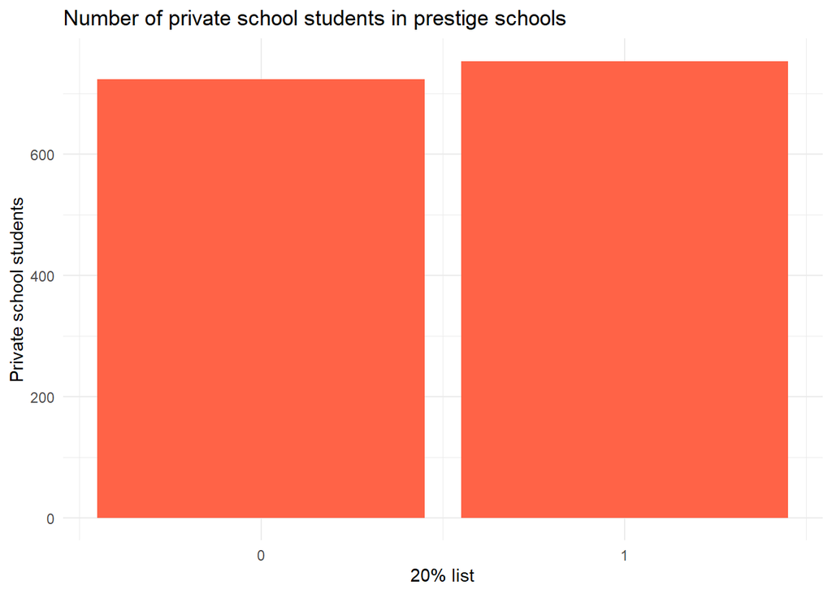

*Graph 1 - This bar graph compares the number of students from private primary schools that are assigned to a prestige school with and without the 20% list in place. 1 represents the affirmative of the axis label, 0 represents the counterfactual.*

The graph demonstrates that there is a slightly greater number of private school students assigned to prestige schools with the 20% list in effect (20% list = 1) compared to the instance where the 20% list is not used (20% list = 0). This gives merit to my hypothesis as it demonstrates an observable difference between the worlds where the 20% list exists and does not exist.

Using the regression models outlined in the previous section, I will determine whether this difference is significant.

### Primary Regression

**Regression Results**

|  | *Dependent variable:* |
| --- | --- |
|  | 20% list in effect |
| Private | 0.026* |
|  | (0.014) |
| Composite | -0.001*** |
|  | (0.0004) |
| Constant | 0.773*** |
|  | (0.094) |
| Observations | 11,297 |
| R<sup>2</sup> | 0.001 |
| Adjusted R<sup>2</sup> | 0.001 |
| Residual Std. Error | 0.500 (df = 11294) |
| F Statistic | 5.140*** (df = 2; 11294) |
| *Note:* | *p<0.1; **p<0.05;*** p<0.01 |

According to this regression, when the 20% list is in effect, private school students have a 2.6% greater chance than non-private school students of being assigned to a prestige school. This effect could be considered substantial given that private primary school students constitute a very small population.

This effect is NOT significant at the p<0.05 level when students’ composite SEA scores are controlled for. Therefore, I am not able to find a statistically significant relationship and fail to reject the null to my hypothesis. The evidence does not suggest that attending a private primary school increases the likelihood of being assigned to a prestige school.

### Empirical Extension Results

|  | *Dependent variable:* |  |  |  |  |  |
| --- | --- | --- | --- | --- | --- | --- |
|  | Effect at different levels |  |  |  |  |  |
|  | Top 10 F | Top 10 M | 11-20 F | 11-20 M | 21-30 F | 21-30 M |
|  | (1) | (2) | (3) | (4) | (5) | (6) |
| Private | 0.032 | 0.033 | 0.049 | -0.014 | -0.045 | 0.090 |
|  | (0.026) | (0.028) | (0.044) | (0.039) | (0.044) | (0.058) |
| Composite | -0.010*** | -0.008*** | -0.006*** | -0.004*** | 0.005** | 0.004*** |
|  | (0.002) | (0.002) | (0.002) | (0.002) | (0.002) | (0.001) |
| Constant | 2.964*** | 2.376*** | 1.787*** | 1.528*** | -0.708 | -0.306 |
|  | (0.399) | (0.359) | (0.367) | (0.373) | (0.544) | (0.283) |
| Observations | 2,162 | 1,858 | 1,712 | 1,456 | 1,280 | 1,184 |
| R<sup>2</sup> | 0.019 | 0.015 | 0.008 | 0.005 | 0.005 | 0.009 |
| Adjusted R<sup>2</sup> | 0.018 | 0.014 | 0.007 | 0.004 | 0.003 | 0.007 |
| Residual Std. Error | 0.496 (df = 2159) | 0.497 (df = 1855) | 0.498 (df = 1709) | 0.499 (df = 1453) | 0.499 (df = 1277) | 0.498 (df = 1181) |
| F Statistic | 20.512*** (df = 2; 2159) | 14.403*** (df = 2; 1855) | 6.671*** (df = 2; 1709) | 3.797** (df = 2; 1453) | 2.967* (df = 2; 1277) | 5.371*** (df = 2; 1181) |
| *Note:* | *p<0.1; **p<0.05;*** p<0.01 |  |  |  |  |  |

Similar to the primary regression, these regression results show that when the 20% list in in effect, private primary school students are not more likely to attend a prestige school. This table in particular demonstrates that this lack of an effect holds for 3 different levels of prestige secondary schools and across sex.

## Discussion and Conclusion

This study has not yielded significant results. As explained above, it could be the case that my hypothesis is not based in reality or it could be the case that the study design is faulty and requires greater statistical power. Additionally, private school attendance is not the most effective proxy for wealth. Having more accurate wealth data such as family income would be useful for the internal and external validity of this study. Also, I am only using 2017 SEA data. Therefore, I am concerned about the external validity of my findings, particularly because the Concordat has been around since the 1960s. It is possible that my findings are unique to 2017 and is not representative of other years.

Future research should use a larger dataset and better measures of family wealth. Also, a qualitative component that gets at the heart of the 20% list decision making process could prove invaluable such as a thematic analysis of interviews with past and present principals who have created 20% lists for their institutions.

It is my hope that I can add to the conversation about the Concordat and the 20% list in a meaningful, empirical way. If it turns out that the Concordat poses a threat to equity or perpetuates a system of elitism, I hope to be a voice of change. At the least, I hope that this study can demystify a currently opaque process.

## References

Barrow, Dorian A., and Samuel N. Lochan. 2012. “Supplementary Tutoring in Trinidad and Tobago: Some Implications for Policy Making.” *International Review of Education* 58 (3): 405–22. https://doi.org/10.1007/s11159-012-9288-2.

Beuermann, Diether, C. Kirabo Jackson, and Ricardo Sierra. 2015. “Privately Managed Public Secondary Schools and Academic Achievement in Trinidad and Tobago: Evidence from Rule-Based Student Assignments.” *IDB Publications*, November. https://doi.org/10.18235/0000213.

Campbell, Carl C. 1997. *Endless Education: Main Currents in the Education System of Modern Trinidad and Tobago, 1939-1986*. Press University of the West Indies. https://www.proquest.com/docview/59777330?https://hdl.library.upenn.edu/1017/7000&parentSessionId=5%2BUPMckGOQBzWuq2VpXfrvR5%2FinP7BGduxHJt%2B5Tjj0%3D&pq-origsite=summon&sourcetype=Books.

Cunningham, Victoria Maria. 2021. “The Impact of High-Stakes Testing: The Experiences of Educators, Students, and Parents in Trinidad and Tobago.” University of Sheffield. https://etheses.whiterose.ac.uk/31474/.

“Education Statistics - Central Statistical Office.” 2021. *Https://Cso.gov.tt/*. https://cso.gov.tt/subjects/population-and-vital-statistics/education-statistics/.

Gorard, Stephen, and Nadia Siddiqui. 2019. “How Trajectories of Disadvantage Help Explain School Attainment.” *Sage Open* 9 (1): 2158244018825171. https://doi.org/10.1177/2158244018825171.

Jackson, C. Kirabo. 2013. “Can Higher-Achieving Peers Explain the Benefits to Attending Selective Schools? Evidence from Trinidad and Tobago.” *Journal of Public Economics* 108: 63–77. https://doi.org/https://doi.org/10.1016/j.jpubeco.2013.09.007.

Lisle, Jerome De, Carol Keller, Vena Jules, and Peter Smith. 2009. “When Choosing Might Mean Losing: A Mixed Method Study of Secondary School Choice in the Republic of Trinidad and Tobago.” *Caribbean Curriculum* 16 (1): 131–76. https://journals.sta.uwi.edu/ojs/index.php/cc/article/view/596.

London, Norrel A. 1997. “Educational Planning and Its Implementation in Trinidad and Tobago.” *Comparative Education Review* 41 (3): 314–30. https://www.jstor.org/stable/1188949.

Mackenzie, Clayton G. 1989. “The Eleven‐plus Examination in Developing Countries: A Case Study.” *Educational Studies* 15 (3): 281–300. https://doi.org/10.1080/0305569890150306.

“Ministry of Education – MOE Access: Service, Systems & Solutions.” n.d. Accessed April 11, 2024. https://www.moe.gov.tt/.

“Policy Documents – Ministry of Education.” n.d. Accessed February 26, 2024. https://www.moe.gov.tt/policy-documents/.